# Project: Train a Quadcopter How to Fly

Design an agent to fly a quadcopter, and then train it using a reinforcement learning algorithm of your choice!

Try to apply the techniques you have learnt, but also feel free to come up with innovative ideas and test them.

## Instructions

Take a look at the files in the directory to better understand the structure of the project.

- `task.py`: Define your task (environment) in this file.
- `agents/`: Folder containing reinforcement learning agents.
  - `policy_search.py`: A sample agent has been provided here.
  - `agent.py`: Develop your agent here.
- `physics_sim.py`: This file contains the simulator for the quadcopter. **DO NOT MODIFY THIS FILE**.

For this project, you will define your own task in `task.py`. Although we have provided a example task to get you started, you are encouraged to change it. Later in this notebook, you will learn more about how to amend this file.

You will also design a reinforcement learning agent in `agent.py` to complete your chosen task.

You are welcome to create any additional files to help you to organize your code. For instance, you may find it useful to define a `model.py` file defining any needed neural network architectures.

## Controlling the Quadcopter

We provide a sample agent in the code cell below to show you how to use the sim to control the quadcopter. This agent is even simpler than the sample agent that you'll examine (in `agents/policy_search.py`) later in this notebook!

The agent controls the quadcopter by setting the revolutions per second on each of its four rotors. The provided agent in the `Basic_Agent` class below always selects a random action for each of the four rotors. These four speeds are returned by the `act` method as a list of four floating-point numbers.

For this project, the agent that you will implement in `agents/agent.py` will have a far more intelligent method for selecting actions!

```python
import random

class Basic_Agent():
    def __init__(self, task):
        self.task = task

    def act(self):
        new_thrust = random.gauss(450., 25.)
        return [new_thrust + random.gauss(0., 1.) for x in range(4)]
```

Run the code cell below to have the agent select actions to control the quadcopter.

Feel free to change the provided values of `runtime`, `init_pose`, `init_velocities`, and `init_angle_velocities` below to change the starting conditions of the quadcopter.

The `labels` list below annotates statistics that are saved while running the simulation. All of this information is saved in a text file `data.txt` and stored in the dictionary `results`.

```python
%load_ext autoreload
%autoreload 2

import csv
import numpy as np
from task import Task

# Modify the values below to give the quadcopter a different starting position.
runtime = 5.                                     # time limit of the episode
init_pose = np.array([0., 0., 10., 0., 0., 0.])  # initial pose
init_velocities = np.array([0., 0., 0.])         # initial velocities
init_angle_velocities = np.array([0., 0., 0.])   # initial angle velocities
file_output = 'data.txt'                         # file name for saved results

# Setup
task = Task(init_pose, init_velocities, init_angle_velocities, runtime)
agent = Basic_Agent(task)
done = False
labels = ['time', 'x', 'y', 'z', 'phi', 'theta', 'psi', 'x_velocity',
          'y_velocity', 'z_velocity', 'phi_velocity', 'theta_velocity',
          'psi_velocity', 'rotor_speed1', 'rotor_speed2', 'rotor_speed3', 'rotor_speed4']
results = {x : [] for x in labels}

# Run the simulation, and save the results.
with open(file_output, 'w') as csvfile:
    writer = csv.writer(csvfile)
    writer.writerow(labels)
    while True:
        rotor_speeds = agent.act()
        _, _, done = task.step(rotor_speeds)
        to_write = [task.sim.time] + list(task.sim.pose) + list(task.sim.v) + list(task.sim.angular_v) + list(rotor_speeds)
        for ii in range(len(labels)):
            results[labels[ii]].append(to_write[ii])
        writer.writerow(to_write)
        if done:
            break
```

Run the code cell below to visualize how the position of the quadcopter evolved during the simulation.

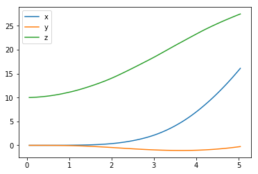

```python
import matplotlib.pyplot as plt
%matplotlib inline

plt.plot(results['time'], results['x'], label='x')
plt.plot(results['time'], results['y'], label='y')
plt.plot(results['time'], results['z'], label='z')
plt.legend()
_ = plt.ylim()
```

The next code cell visualizes the velocity of the quadcopter.

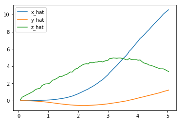

```python
plt.plot(results['time'], results['x_velocity'], label='x_hat')
plt.plot(results['time'], results['y_velocity'], label='y_hat')
plt.plot(results['time'], results['z_velocity'], label='z_hat')
plt.legend()
_ = plt.ylim()
```

Next, you can plot the Euler angles (the rotation of the quadcopter over the $x$-, $y$-, and $z$-axes),

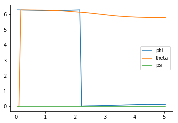

```python
plt.plot(results['time'], results['phi'], label='phi')
plt.plot(results['time'], results['theta'], label='theta')
plt.plot(results['time'], results['psi'], label='psi')
plt.legend()
_ = plt.ylim()
```

before plotting the velocities (in radians per second) corresponding to each of the Euler angles.

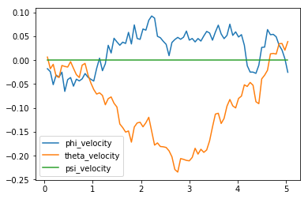

```python
plt.plot(results['time'], results['phi_velocity'], label='phi_velocity')
plt.plot(results['time'], results['theta_velocity'], label='theta_velocity')
plt.plot(results['time'], results['psi_velocity'], label='psi_velocity')
plt.legend()
_ = plt.ylim()
```

Finally, you can use the code cell below to print the agent's choice of actions.

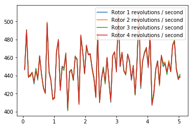

```python
plt.plot(results['time'], results['rotor_speed1'], label='Rotor 1 revolutions / second')
plt.plot(results['time'], results['rotor_speed2'], label='Rotor 2 revolutions / second')
plt.plot(results['time'], results['rotor_speed3'], label='Rotor 3 revolutions / second')
plt.plot(results['time'], results['rotor_speed4'], label='Rotor 4 revolutions / second')
plt.legend()
_ = plt.ylim()
```

When specifying a task, you will derive the environment state from the simulator. Run the code cell below to print the values of the following variables at the end of the simulation:

- `task.sim.pose` (the position of the quadcopter in ($x,y,z$) dimensions and the Euler angles),
- `task.sim.v` (the velocity of the quadcopter in ($x,y,z$) dimensions), and
- `task.sim.angular_v` (radians/second for each of the three Euler angles).

```python
# the pose, velocity, and angular velocity of the quadcopter at the end of the episode
print(task.sim.pose)
print(task.sim.v)
print(task.sim.angular_v)
```

```
[16.10986392 -0.2537901  27.4799528   0.11868227  5.80184538  0.        ]
[10.55516482  1.22540679  3.39094441]
[-0.02527696  0.03899653  0.        ]
```

In the sample task in `task.py`, we use the 6-dimensional pose of the quadcopter to construct the state of the environment at each timestep. However, when amending the task for your purposes, you are welcome to expand the size of the state vector by including the velocity information. You can use any combination of the pose, velocity, and angular velocity - feel free to tinker here, and construct the state to suit your task.

## The Task

A sample task has been provided for you in `task.py`. Open this file in a new window now.

The `__init__()` method is used to initialize several variables that are needed to specify the task.

- The simulator is initialized as an instance of the `PhysicsSim` class (from `physics_sim.py`).
- Inspired by the methodology in the original DDPG paper, we make use of action repeats. For each timestep of the agent, we step the simulation `action_repeats` timesteps. If you are not familiar with action repeats, please read the **Results** section in [the DDPG paper](https://arxiv.org/abs/1509.02971).
- We set the number of elements in the state vector. For the sample task, we only work with the 6-dimensional pose information. To set the size of the state (`state_size`), we must take action repeats into account.
- The environment will always have a 4-dimensional action space, with one entry for each rotor (`action_size=4`). You can set the minimum (`action_low`) and maximum (`action_high`) values of each entry here.
- The sample task in this provided file is for the agent to reach a target position. We specify that target position as a variable.

The `reset()` method resets the simulator. The agent should call this method every time the episode ends. You can see an example of this in the code cell below.

The `step()` method is perhaps the most important. It accepts the agent's choice of action `rotor_speeds`, which is used to prepare the next state to pass on to the agent. Then, the reward is computed from `get_reward()`. The episode is considered done if the time limit has been exceeded, or the quadcopter has travelled outside of the bounds of the simulation.

In the next section, you will learn how to test the performance of an agent on this task.

## The Agent

The sample agent given in `agents/policy_search.py` uses a very simplistic linear policy to directly compute the action vector as a dot product of the state vector and a matrix of weights. Then, it randomly perturbs the parameters by adding some Gaussian noise, to produce a different policy. Based on the average reward obtained in each episode (`score`), it keeps track of the best set of parameters found so far, how the score is changing, and accordingly tweaks a scaling factor to widen or tighten the noise.

Run the code cell below to see how the agent performs on the sample task.

```python
import sys
import pandas as pd
from agents.policy_search import PolicySearch_Agent
from task import Task

num_episodes = 1000
target_pos = np.array([0., 0., 10.])
task = Task(target_pos=target_pos)
agent = PolicySearch_Agent(task)

for i_episode in range(1, num_episodes+1):
    state = agent.reset_episode() # start a new episode
    while True:
        action = agent.act(state)
        next_state, reward, done = task.step(action)
        agent.step(reward, done)
        state = next_state
        if done:
            print("\rEpisode = {:4d}, score = {:7.3f} (best = {:7.3f}), noise_scale = {}".format(
                i_episode, agent.score, agent.best_score, agent.noise_scale), end="")  # [debug]
            break
    sys.stdout.flush()
```

```
Episode = 1000, score =  -1.508 (best =  -0.045), noise_scale = 3.25
```

This agent should perform very poorly on this task. And that's where you come in!

## Define the Task, Design the Agent, and Train Your Agent!

Amend `task.py` to specify a task of your choosing. If you're unsure what kind of task to specify, you may like to teach your quadcopter to takeoff, hover in place, land softly, or reach a target pose.

After specifying your task, use the sample agent in `agents/policy_search.py` as a template to define your own agent in `agents/agent.py`. You can borrow whatever you need from the sample agent, including ideas on how you might modularize your code (using helper methods like `act()`, `learn()`, `reset_episode()`, etc.).

Note that it is **highly unlikely** that the first agent and task that you specify will learn well. You will likely have to tweak various hyperparameters and the reward function for your task until you arrive at reasonably good behavior.

As you develop your agent, it's important to keep an eye on how it's performing. Use the code above as inspiration to build in a mechanism to log/save the total rewards obtained in each episode to file. If the episode rewards are gradually increasing, this is an indication that your agent is learning.

### My work begins here

This sections will describe my project in its three phases:

1. First attempt of implementing a DDPG agent for the quadcopter project and roadblocks encountered
2. Implementing a DDPG agent on MountainCarContinuous to check the validity of the implementation
3. Apply lessons learned to quadcopter project

```python
%%javascript
IPython.OutputArea.prototype._should_scroll = function(lines) {
    return false;
}
```

#### First attempt Quadcopter project

I first took the example code from the project supplemental for the DDPG implementation as well as the standard Task code unchanged. As recommended by the project and in discussion with other students and mentors, I started designing the reward function first. In this first attempt I did not change the Actor or Critic architectures but only tried different hyperparameters on my modified reward function.

The most important changes to the default reward function were:

1. Informing the agent about success and terminating the episode on success
2. Terminating the episode on crashes and out-of-bound flights
3. Defining a solution condition

The details for 1.) and 2.) are outlined in the Reflection section below.

For 3.) I included a check that counts the number of successful (as in reaches the goal) flights over the past X episodes. The threshold I went with was that the problem was considered solved if the agent reaches the goal 9 times out of the last 10 episodes.

#### Task

I went for a relatively straightforward task for the Quadcopter: Taking off from the initial position and reaching a position straight up along the Z axis. I went at this in steps of increasing distance with target positions (0,0,30), (0,0,50), (0,0,100) from a starting position (0,0,10).

The task definitely becomes more difficult as the distance increases. On the one hand very slight drift in X or Y positions can make the copter shoots past the goal if the goal is sufficiently away from the starting position. On the other hand, to reach a height of 100 from the initial position the copter pretty much has to set all rotors to max to make the distance in the short default simulation time of 5 seconds. I did not change the simulation time.

#### Experimentation Mess

After a while I was getting lost in experimenting with hyperparameters and plotting the results of the many experiments I ran. I initially tracked the results in a spreadsheet, but with more and more changes in hyperparemeters and code, this proved insufficient to keep track on which changes were really making a difference.

The original hyperparameter changelog can be found in quadcopter_hyperparameters.xlsx.

To solve the mess I implemented my own experimentation infrastructure outside of Jupyter using [Sacred](https://sacred.readthedocs.io) for recording experiments and [Omniboard](https://github.com/vivekratnavel/omniboard) for reporting on results and experiment parameters.

The code for the infrastructure is included with this project in sacredrun.py and an export of the experiment history as well. Below screenshot shows an example recording of an early quadcopter experiment in Sacred.

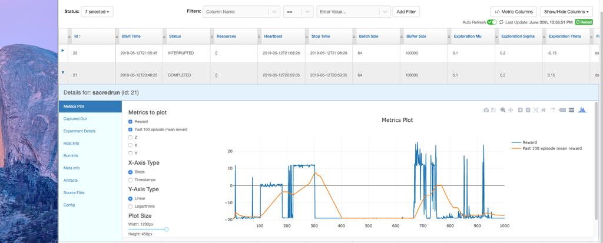

Below follows a re-implementation of the sacred experiments in Jupyter.

First, all hyperparameters and training configuration are set as global variables. This is what Sacred would do for me in my experimentation phase of the project. Agent, task, and experiment parameters can be configured.

Different agents can be tested against the Task interface. The agents implemented are:

- DDPG_Agent: This is the main agent written for this project
- DDPG_Agent_Simple: This is the DDPG agent with minimal changes from the Udacity project supplemental
- Policy_Search: This is the policy search agent from above introduction
- Random_Binary_Agent: This is a benchmark agent for DDPG, see below

The first set of executions in this notebook will refer to running the experiment with DDPG_Agent_Simple as per the initial experiments described above. Further down the notebook I discuss the final DDPG_Agent and the results.

```python
import sys
import numpy as np
import visuals as vs
import pandas as pd

from agents.agent import DDPG_Agent
from agents.policy_search import PolicySearch_Agent
from agents.random_binary_agent import Random_Binary_Agent
from agents.agent_simple import DDPG as DDPG_Agent_Simple
from collections import deque
from tasks import TakeOff_Task

# Noise process
exploration_mu = 0.
exploration_theta = 0.15
exploration_sigma = 0.2

# Replay memory
buffer_size = 100000
batch_size = 256

# Algorithm parameters
gamma = 0.99   # discount factor
tau = 0.1  # for soft update of target parameters

# Experiment
num_episodes = 1000
runtime = 5.
success_mem_len = 10
minimum_successes = 9

# Task parameters
init_velocities = np.array([.1, .1, .1])         # initial velocities
init_angle_velocities = np.array([0., 0., 0.])   # initial angle velocities
file_output = 'data.txt'                         # file name for saved results
init_pose = np.array([0., 0., 10., 0., 0., 0.])  # initial pose
action_low = 10
action_high = 900
action_size = 4
action_repeat = 3
target_pos = np.array([0., 0., 50.])
success_distance = 2

# experiment logging parameters
n_mean = 100

# which agent to run
agents = ['DDPG', 'Policy_Search', 'Random_Binary', 'Simple']
agent_type = agents[3]


task = TakeOff_Task(target_pos=target_pos, init_pose=init_pose,
            init_angle_velocities=init_angle_velocities, init_velocities=init_velocities,
            runtime=runtime)

task.configure(action_repeat=action_repeat, action_low=action_low, action_high=action_high, action_size=action_size,
               target_pos=target_pos, init_velocities=init_velocities, init_angle_velocities=init_angle_velocities,
               init_pose=init_pose, success_distance=success_distance)

if agent_type == 'DDPG':
    agent = DDPG_Agent(task)
    agent.configure(gamma, tau, buffer_size, batch_size, exploration_mu, exploration_theta, exploration_sigma)
if agent_type == 'Policy_Search':
    agent = PolicySearch_Agent(task)
if agent_type == 'Random_Binary':
    agent = Random_Binary_Agent(task)
    agent.configure(success_mem_len)
if agent_type == 'Simple':
    agent = DDPG_Agent_Simple(task)
    agent.configure(gamma, tau, buffer_size, batch_size, exploration_mu, exploration_theta, exploration_sigma)
```

[output not shown]

After the agent is selected and configured, the training loop is run. This implementation leans on the training loop of Policy Search agent above, with a few changes:

- A solution condition is included which will break the loop if 9 out of the last 10 episodes were successful.
- An exploration / exploitation tradeoff is modeled as a function p which reduces exploration continuously until it reaches 0 at about 2/3 of total episodes
- The Task and the loop record which episodes were successful in reaching the goal
- The loop can be interrupted without discarding statistics collected until this point

```python
def train_quadcopter(agent):

    rewards = np.array([])
    successes = deque([], maxlen=success_mem_len)

    labels = ['Episode', 'Reward', 'time', 'x', 'y', 'z', 'phi', 'theta', 'psi', 'x_velocity',
              'y_velocity', 'z_velocity', 'phi_velocity', 'theta_velocity',
              'psi_velocity', 'rotor1', 'rotor2', 'rotor3', 'rotor4', 'p', 'success']
    results = []
    try:
        for i_episode in range(1, num_episodes + 1):
            state = agent.reset_episode()  # start a new episode
            total_reward = 0.

            p = 1 - (i_episode / (num_episodes * 0.7)) ** 2  # exploration / exploitation trade off
            p = max(p, 0)

            actions = []

            while True:
                action = agent.act(state, p)
                next_state, reward, done = task.step(action)
                agent.step(action, reward, next_state, done)
                state = next_state
                total_reward += reward

                actions.append(action)

                result = {a : 0. for a in labels}

                result['Episode'] = i_episode
                result['Reward'] = reward
                result['time'] = task.sim.time
                result['x'] = task.sim.pose[0]
                result['y'] = task.sim.pose[1]
                result['z'] = task.sim.pose[2]
                result['phi'] = task.sim.pose[3]
                result['theta'] = task.sim.pose[4]
                result['psi'] = task.sim.pose[5]
                result['x_velocity'] = task.sim.v[0]
                result['y_velocity'] = task.sim.v[1]
                result['z_velocity'] = task.sim.v[2]
                result['phi_velocity'] = task.sim.angular_v[0]
                result['theta_velocity'] = task.sim.angular_v[1]
                result['psi_velocity'] = task.sim.angular_v[2]
                result['rotor1'] = action[0]
                result['rotor2'] = action[1]
                result['rotor3'] = action[2]
                result['rotor4'] = action[3]
                result['p'] = p
                result['success'] = task.success
                results.append(result)

                if done:

                    actions = np.array(actions).reshape(-1, 4)

                    means = actions.mean(axis=0)
                    stds = actions.std(axis=0)
                    mins = actions.min(axis=0)
                    maxs = actions.max(axis=0)

                    print("\rEpisode = {:4d}, Reward = {:8.4f}, {:7} ({:.2f}), Rotors mean: {:03.0f} {:03.0f} {:03.0f} {:03.0f}".format(
                            i_episode, total_reward, ('Success' if agent.task.success else 'Fail ({})'.format(agent.task.outcome)),
                            agent.task.distance_to_target, means[0], means[1], means[2], means[3]), end="")
                    '''
                    print("\r{:>60}std:  {:03.0f} {:03.0f} {:03.0f} {:03.0f}".format('',
                        stds[0], stds[1], stds[2], stds[3], end=""
                    ))
                    print("\r{:>60}min:  {:03.0f} {:03.0f} {:03.0f} {:03.0f}".format('',
                        mins[0], mins[1], mins[2], mins[3], end=""
                    ))
                    print("\r{:>60}max:  {:03.0f} {:03.0f} {:03.0f} {:03.0f}".format('',
                        maxs[0], maxs[1], maxs[2], maxs[3], end=""
                    ))
'''
                    total_reward = 0
                    successes.append(agent.task.success)
                    break

            if sum(successes) >= minimum_successes:
                print("\nTask solved!")
                break
            sys.stdout.flush()
    except KeyboardInterrupt:
        results = pd.DataFrame(results)
        return results.loc[results['Episode'] != results['Episode'].max()]
    return pd.DataFrame(results)

results_train_ddpg_simple = train_quadcopter(agent)
```

```
Episode =   10, Reward = -43.5032, Fail (2) (50.50), Rotors mean: 564 430 130 775WARNING:tensorflow:From /home/mes/anaconda3/envs/quadcop/lib/python3.6/site-packages/tensorflow/python/ops/math_ops.py:3066: to_int32 (from tensorflow.python.ops.math_ops) is deprecated and will be removed in a future v…
Instructions for updating:
Use tf.cast instead.
Episode =   24, Reward = 114.3246, Success (1.98), Rotors mean: 900 900 900 90000
Task solved!
```

If the training loop executed successfully, was interrupted, or if the maximum episodes are reached, all training data is collected in the results object returned by the training loop.

visuals.py contains a number of helpers for visualizing training and final performance on the agents. Below follows a set of plots documenting the training behavior, and a set of plots visualizing the flight behavior of the agent over the most recent episodes following the learned policy, as well as the behavior during the best episode in terms of return reward.

Code for the visualization was inspired by the quadcopter best practices post by F Wittmann: https://github.com/WittmannF/quadcopter-best-practices

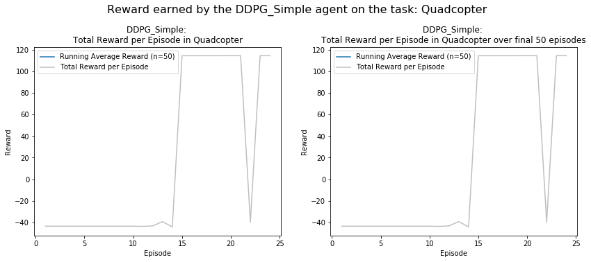

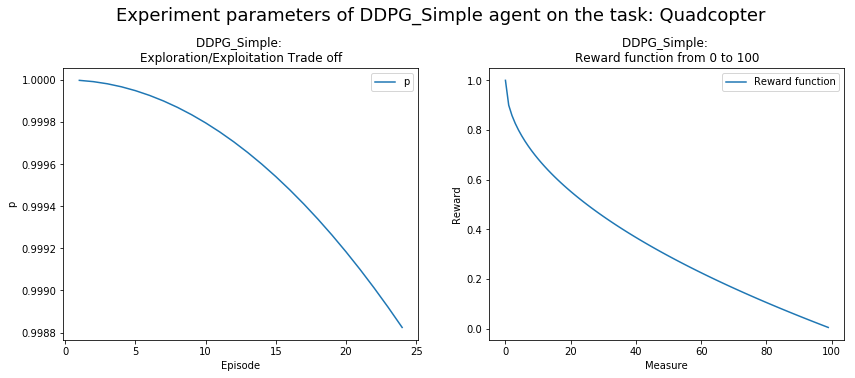

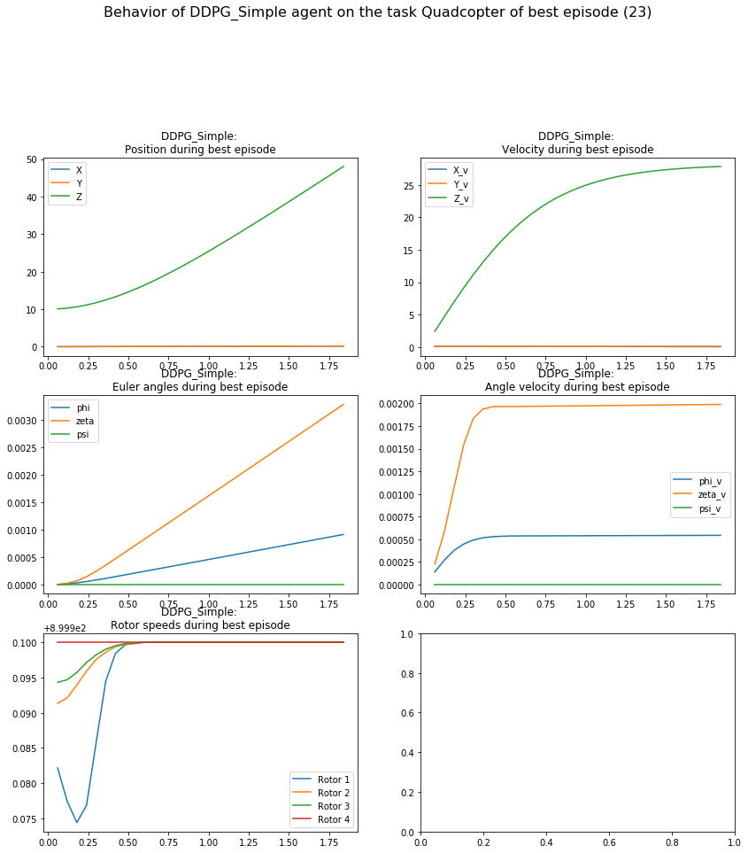

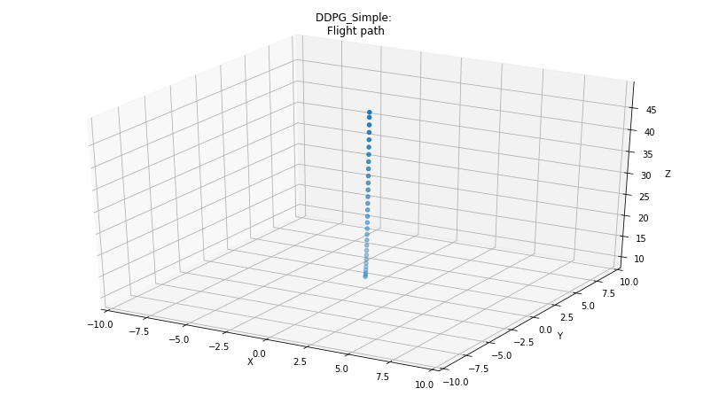

```python
# to visualize the slope of the continuous reward given:
reward_function = lambda x: 1 - (x / (100)) ** .5

vs.plot_training_rewards(results_train_ddpg_simple, 'DDPG_Simple', 'Quadcopter', 50, verbose=True, reward_function=reward_function)
vs.plot_quad_behavior(results_train_ddpg_simple, 'DDPG_Simple', 'Quadcopter')
```

#### Interpretation

After much experimentation, the agent did reach the target pose somewhat regularly, if the target pose was not higher than (0,0,50). I could increase the chance the agent discoved a successful flight policy by increase tau to a rate between 0.1 and 0.9.

However, this made the training process incredibly unstable. It appears the higher tau introduces more volatility in the exploration direction of the agent. This makes sense looking how tau is applied. A higher tau decreases the "inertia" of the live policy and applies more of the policy being trained.

Overall this meant that the agent would try different rotor speeds rather wildly and all over the place, which would lead it after a while - if chance allows - to set the rotors to high and rise towards the target. Once a successful flight was found this did not translate into a permanently usable policy though, as on future episodes the agent would again show wild fluctuations in choosing rotor speeds.

Upon further examination, the quadcopter would reach the intended target pose (straight up) when it found one of 3 actions policy types:

1. All rotors to max (900,900,900,900). Once this policy was found, the agents shoots straight up, reaching the target.
2. 2 rotors to max, 2 rotors off (900,900,10,10). This behaves very similar to 1), but makes the copter wobble a little more judging by the Euler angle plot.
3. 2 rotors to max, 2 rotors off (10,10,900,900). This behaves very similar to 1), but makes the copter wobble a little more judging by the Euler angle plot.

Note: 10 is the minimum speed of a rotor. I set it to 10 as a minimum speed of 0 would occasionally cause devision by zero errors in the physics simulation.

My interpretation of this is that the action tuple states rotor position diagonally. If we imagine the rotor positions as a 2 by 2 grid, the action tuple translates to ((1,1), (2,2), (1,2), (2,1)). This would explain why rotor 1 and 2 on full speed and rotors 3 and 4 off results in a flight path straight up.

#### Roadblock

Further examination of the training process revealed the following behavior: After some initial very varied applications of rotor speeds across the whole action range, the agent would choose either the minimum or the maximum speed for a rotor.

Intuitively, this would make it next to impossible for the agent to reach a target that is off the Z-axis relative to the starting position. (Except for a hypothetical violent on-off oscillation on every timestep. The agent never showed this behavior in training though. Once it settled on either the minimum or maximum speed for a rotor, it would not change this behavior anymore).

I confirmed this by trying to reach any pose off the previous target with respect to X and Y, for example (10,10,50), still starting at (0,0,10). The agent was unable to get to that position. The best result it got for this new task was following the same policy as the original task: Setting all rotors to max, and shooting straight up, past the target pose. It never showed any effort to fly towards the target.

This was a major roadblock and I was unable to modify the agent or the task in a way to reliably get a learning behavior that did not eventually result in the agent setting the rotors to either minimum or maximum. Changes to the reward function or the hyperparameters would only influence how quickly the agent reaches the minimum or maximum policy for each rotor. Depending on the hyperparameters this was usually between 15 and 50 episodes.

Once it arrived at this behavior it would very very rarely deviate from it, maybe once over 1000 episodes. I tested this by letting the agent run for 500,000 episodes, but after 1500 episodes it would not deviate from its minimum or maximum policy for each rotor anymore.

This roadblock is described in detail in https://knowledge.udacity.com/questions/43686

It's here that I started changing the network architecture, changing the reward function, extensively trying different hyper parameter combinations. In between I tossed out the whole project twice and started from scratch, however I would always arrive a the same problem, and I was unable to get the agent to choose actions other than minimum or maximum of the action range, and thus unable to reach any position other than straight up the Z axis.

### MountainCarContinous

With the DDPG agent unable to perform in the Quadcopter environment in a satisfying manner, I decided to validate the approach first on a simpler environment, and one for which a solution heuristic is publically available to compare my agent against. https://github.com/openai/gym/wiki/MountainCarContinuous-v0

As suggested by the project description, I tried my agent on the MountainCar-Continuous OpenAI gym. To make my work transferable between Mountaincar and the Quadcopter projects, I wrote my own wrapper to the Mountaincar environment which implements the same Task interface that the quadcopter project uses.

I had to make a number of changes to the DDPG agent to make it suit the new enviroment, although none of the changes fundamentally change the architecture.

The choices for network architecture of my modifications were inspired by the deep net structure and parameters in the original DDPG paper https://arxiv.org/pdf/1509.02971.pdf.

#### DDPG Changes

```python
from agents.agent_mountaincar import DDPG_Agent as DDPG_Agent_MountainCar
from task_mountaincar import Mountain_Task

# Noise process
exploration_mu = 0.
exploration_theta = 0.05
exploration_sigma = 0.25

# Replay memory
buffer_size = 100000
batch_size = 256

# Algorithm parameters
gamma = 0.99   # discount factor
tau = 0.01

# tau, seperated for actor and critic
tau_actor = 0.01
tau_critic = 0.1

# Experiment
num_episodes = 1000
action_repeat = 3
throttle = 1

# experiment logging parameters
n_mean = 100
write_train_log = False
learn_during_episode = True
monitor = False

task = Mountain_Task(action_repeat=action_repeat, monitor=monitor)

agent = DDPG_Agent_MountainCar(task)
agent.configure(gamma, tau, tau_critic, tau_actor, buffer_size, batch_size, exploration_mu, exploration_theta, exploration_sigma,
                    learn_during_episode, throttle)
```

#### Training the agent

This is an implementation of the training loop of the Quadcopter task and agent, adapted for MountainCar.

I introduce a function p to model the exploration / exploitation tradeoff. Factor p is multiplied with the OU noise in the DDPG agent. The applied noise is continuously reduced until it reaches zero at half the total episodes are over. The other change is that the state is preprocessed before passing it to training. The task returns a raw state, unprocessed, for logging results.

The task is considered solved when the average reward over the past 100 episodes is higher than 90.

```python
def train_mountain():
    labels = ['Episode', 'Reward', 'Position', 'Action', 'Velocity']
    results = pd.DataFrame(columns=labels)
    rewards = []
    for i_episode in range(1, num_episodes + 1):
        state = agent.reset_episode()  # start a new episode
        total_reward = 0.0
        actions = []
        p = 1 - (i_episode / (num_episodes * 0.5)) ** 0.5  # exploration / exploitation trade off
        p = max(p, 0)

        while True:
            action = agent.act(state, p)
            next_state, reward, done, raw_state = task.step(action)
            agent.step(action, reward, next_state, done)
            state = next_state
            actions.append(action[0])

            results = results.append({'Episode': i_episode, 'Reward': reward, 'Position': raw_state[-1][0],
                                      'Action': action[0], 'Velocity': state[1]},
                           ignore_index=True)
            if done:
                total_reward = results[results.Episode == i_episode][['Reward']].sum()[0]

                print("\rEpisode = {:4d}, Reward = {: 8.4f}, {:7} ({: 2.2f}), Motor (mean/std): {: 03.4f} / {:03.4f}".format(
                    i_episode, total_reward, ('Success' if task.success else 'Fail'),
                    raw_state[-1][0], np.mean(actions), np.std(actions)), end="")

                rewards.append(total_reward)
                break

        if sum(rewards[-100:]) / 100 > 90:
            print('\n\nTask solved!')
            break
        sys.stdout.flush()
    return results

results_train_mountain = train_mountain()
```

```
Episode =  104, Reward =  94.4719, Success ( 0.45), Motor (mean/std):  0.3387 / 0.8459

Task solved!
```

Again I make use of my visualization libary visuals.py to plot the training progress and behavior of the mountaincar:

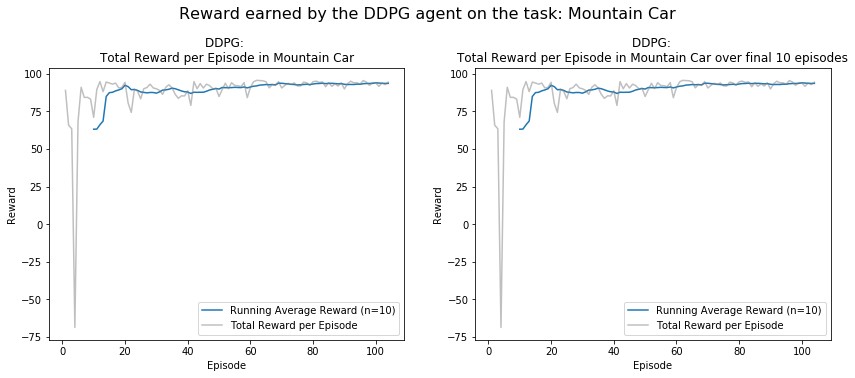

```python
vs.plot_training_rewards(results_train_mountain, 'DDPG', 'Mountain Car', 10)
```

This is a very convincing performance. Usually the solution condition is met within 100-120 episodes. Depending on initialization, it succeeds in reaching the goal of the environment in between 2-15 episodes.

Ploting the behavior of the car with the learned policy:

```python
def test_mountain(monitor=False):
    agent.task.monitor = monitor
    state = agent.reset_episode()
    results = pd.DataFrame(columns=['Step','Position', 'Velocity', 'Action'])
    done = False
    i = 1
    while True:
        action = agent.act(state)
        state, _, done, raw_state = task.step(action)

        results = results.append({'Step': i, 'Position': raw_state[-1][0], 'Velocity': state[1], 'Action': action[0]},
                                 ignore_index=True)
        if done:
            break

        i += 1
    return results
```

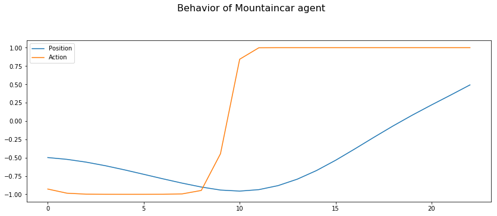

```python
test_results_mountain = test_mountain()
vs.plot_mountaincar_behavior(test_results_mountain)
```

As we can see the agent correcly applies full force up the left side mountain to gain momentum. On the way back it switches to full force forward up the right hill just as it reaches the bottom of the vallye.

The results are even more impressive if we artificially throttle the engine of the mountaincar to 20% power:

```python
throttle = 0.2
agent = DDPG_Agent_MountainCar(task)
agent.configure(gamma, tau, tau_critic, tau_actor, buffer_size, batch_size, exploration_mu, exploration_theta, exploration_sigma,
                    learn_during_episode, throttle)
results_train_mountain = train_mountain()
```

```
Episode =  153, Reward =  96.5162, Fail    ( 0.45), Motor (mean/std):  0.1638 / 0.3536

Task solved!
```

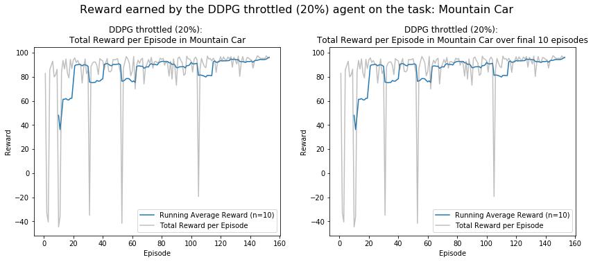

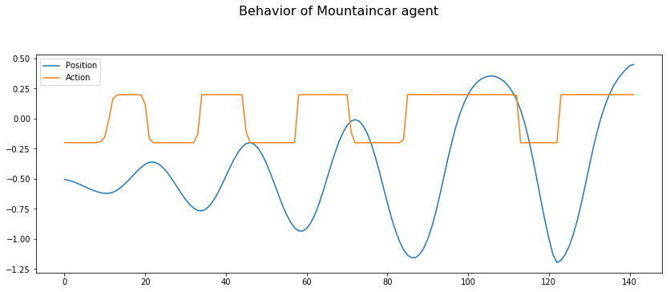

```python
vs.plot_training_rewards(results_train_mountain, 'DDPG throttled (20%)', 'Mountain Car', 10)

test_results_mountain = test_mountain()
vs.plot_mountaincar_behavior(test_results_mountain)
```

As we can see, the agent correctly applies the little power it has to climb up the left hill and right, building more and more moementum, until it can climb the right hill to reach the goal.

The convincing performance of the DDPG agent on MountainCar-Continuous game me a boost to try again on the quadcopter task. I decided to take over the changes I made for MountainCar and adapt them as needed if the quadcopter does not perform.

### Quadcopter revisited

Next, I build a new agent for the quadcopter task based on the changes I had made solving the Mountaincar problem.

- I took over the network architecture inspired by Lillicrap, Timothy P., et al. from my Mountaincar agent
- I changed all layer activations to eLU
- I build my own pre-processing for the state and action space to normalize each to a range between 0 and 1, mirroring the pre-processing I had done for Mountaincar.

Disappointingly, none of these changes that had worked so well for Mountaincar helped with better performance on the Quadcopter task. Quite the opposite, the learning process became incredibly unstable, with the agent wildly choosing action which would make the quadcopter tumble to a crash every episode.

I then decided to move the implementation closer again to the original implementation proposed by Lillicrap, Timothy P., et al., as their paper was meant to propose and architecture that performs well in different physical environment, while my Mountaincar agent was customized to that task. The main change here was switching back to ReLU as the activation on all (non-final) layers. This stabilized the training process in that it again moved closer to the original roadblock encountered with the minimum and maximum values being quickly chosen as a policy by the agent. Experiments with other activations (like LeakyReLU) did not lead to improved learning.

I also took out the pre-processing after a period of experimentation with it. It did not seem to make any difference to the learning process. The original paper by Lillicrap, Timothy P., et al. also does not preprocess state. Further, Lillicrap, Timothy P., et al. demonstrate that their DDPG implementation also performs well on raw image input of the task rather than encoded state space, suggesting that normalizing the state input is not a necessity to make the their DDPG agent work.

The final DDPG Quadcopter implementation uses the network architecture and Actor and Critic hyperparameters proposed by Lillicrap, Timothy P., et al. My changes to the take-off task, the training loop, and the solution condition mirror the experiment above on DDPG_Simple.

Training and performance evaluation of the final DDPG agent within the same framework as the simple agent follows:

```python
# reimport TakeOff_Task to get around the TypeError bug described in
# https://thingspython.wordpress.com/2010/09/27/another-super-wrinkle-raising-typeerror/
from tasks import TakeOff_Task

# which agent to run
agents = ['DDPG', 'Policy_Search', 'Random_Binary', 'Simple']
agent_type = agents[0]

task = TakeOff_Task(target_pos=target_pos, init_pose=init_pose,
            init_angle_velocities=init_angle_velocities, init_velocities=init_velocities,
            runtime=runtime)

task.configure(action_repeat=action_repeat, action_low=action_low, action_high=action_high, action_size=action_size,
               target_pos=target_pos, init_velocities=init_velocities, init_angle_velocities=init_angle_velocities,
               init_pose=init_pose, success_distance=success_distance)

if agent_type == 'DDPG':
    agent = DDPG_Agent(task)
    agent.configure(gamma, tau, buffer_size, batch_size, exploration_mu, exploration_theta, exploration_sigma)
```

Running the training loop, collecting the results for visualization as above with the simple agent:

```python
results_train_ddpg_quad = train_quadcopter(agent)
```

```
Episode =  331, Reward = 114.5294, Success (2.62), Rotors mean: 899 900 900 90000
Task solved!
```

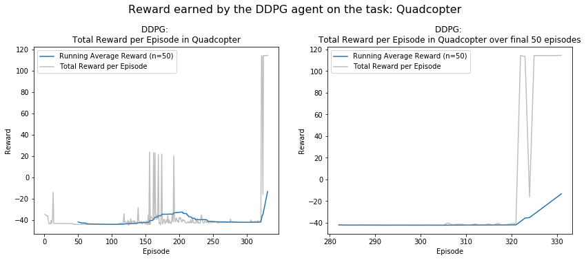

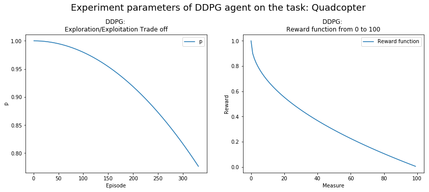

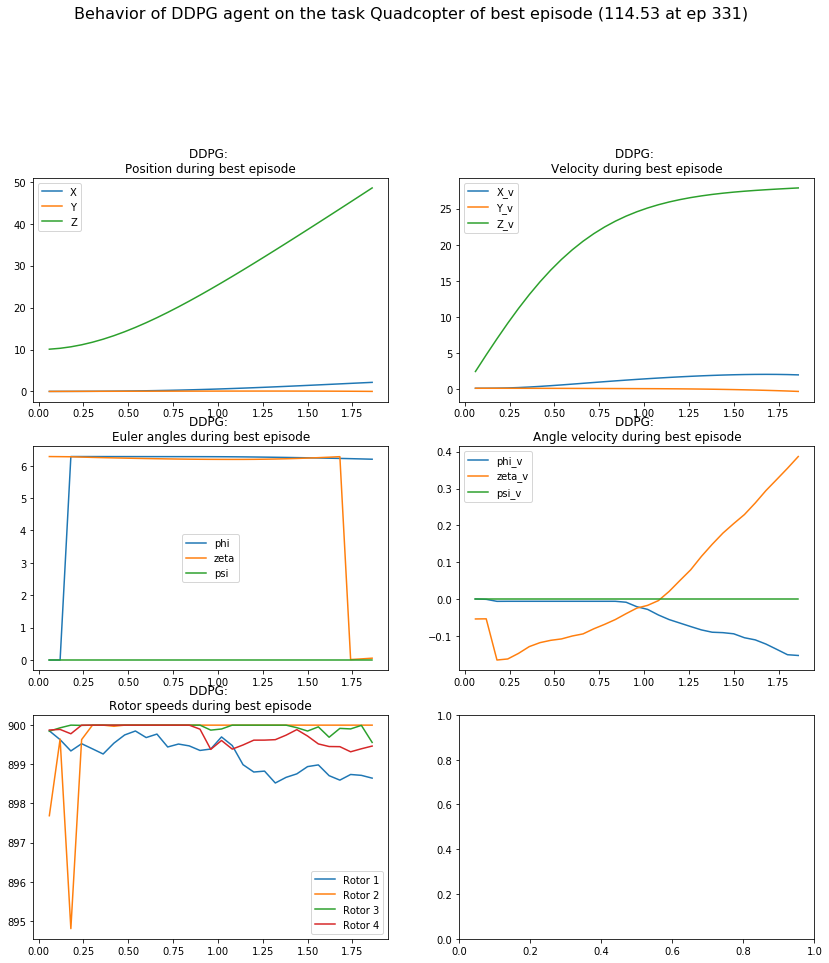

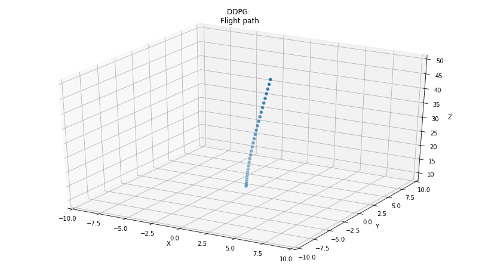

```python
reward_function = lambda x: 1 - (x / (100)) ** .5

vs.plot_training_rewards(results_train_ddpg_quad , 'DDPG', 'Quadcopter', 50, verbose=True, reward_function=reward_function)
vs.plot_quad_behavior(results_train_ddpg_quad , 'DDPG', 'Quadcopter')
```

#### Interpretation

The final DDPG agent does not qualitatively perform better than DDPG_Simple. Both eventually find one of the 3 possible rotor configurations that let's them succeed in the takeoff task. Once they find success, both do learn the successful policy that got them to the target pose, and exploit it in the following episodes until the training loop terminates on the solution condition of consecutive successes.

The DDPG agent after Lillicrap, Timothy P., et al. however appears more stable. This does not translate to faster convergence. Instead, the agent resolves to choosing minimums and maximums for rotor speeds much quicker than the simple DDPG agent does. Presumably this is because of the initializers added to both the Actor and the Critic network.

Once a successful rotor configuration is found by either the simple or the final DDPG agent, both keep that policy in place to solve the task.

Both versions of the DDPG agent depend heavily on initilization, and will not find a working rotor configuration on some training loops. This reliance on initialization is a well known problem of reinforcement learning in general though and not specific to the task at hand. Compare Alexir Pan's article on contemporary limitations of reinforcement learning: https://www.alexirpan.com/2018/02/14/rl-hard.html

#### Random Binary agent

I implemented another agent, Random_Binary_Agent, which mimicks the behavior of my DDPG attempts, if grossly simplified. It chooses either the minimum or maximum value for a rotor, and keeps this policy in place until it is sure to not succeed with it. It then goes back and tries a different randomly chosen combination of minimum and maximum rotor speeds.

This was meant as a half-serious benchmark agent to test DDPG against. As disheartening as it is, Random_Binary remains unbeaten at the quadcopter task, especially taking into account computation necessary.

```python
# reimport TakeOff_Task to get around the TypeError bug described in
# https://thingspython.wordpress.com/2010/09/27/another-super-wrinkle-raising-typeerror/
from tasks import TakeOff_Task

# which agent to run
agents = ['DDPG', 'Policy_Search', 'Random_Binary', 'Simple']
agent_type = agents[2]

task = TakeOff_Task(target_pos=target_pos, init_pose=init_pose,
            init_angle_velocities=init_angle_velocities, init_velocities=init_velocities,
            runtime=runtime)

task.configure(action_repeat=action_repeat, action_low=action_low, action_high=action_high, action_size=action_size,
               target_pos=target_pos, init_velocities=init_velocities, init_angle_velocities=init_angle_velocities,
               init_pose=init_pose, success_distance=success_distance)

if agent_type == 'Random_Binary':
    agent = Random_Binary_Agent(task)
    agent.configure(success_mem_len)
```

```python
results_train_binary_quad = train_quadcopter(agent)
```

```
new best score 32.60134003562152, new policy 10 900 10 900
Episode =   13, Reward =  32.6013, Fail (3) (13.96), Rotors mean: 010 900 010 900new best score 32.60134003562152, new policy 10 10 10 900
Episode =   26, Reward = -43.2676, Fail (2) (50.01), Rotors mean: 010 010 010 900new best score 32.60134003562152, new policy 900 10 10 10
Episode =   39, Reward = -43.1887, Fail (2) (50.03), Rotors mean: 900 010 010 010new best score 32.60134003562152, new policy 900 900 900 10
Episode =   52, Reward = -42.1264, Fail (2) (50.48), Rotors mean: 900 900 900 010new best score 32.60134003562152, new policy 10 900 900 10
Episode =   65, Reward = -13.0395, Fail (4) (80.41), Rotors mean: 010 900 900 010new best score 123.52257436910268, new policy 10 10 900 900
Episode =   74, Reward = 123.5226, Success (1.83), Rotors mean: 010 010 900 900
Task solved!
```

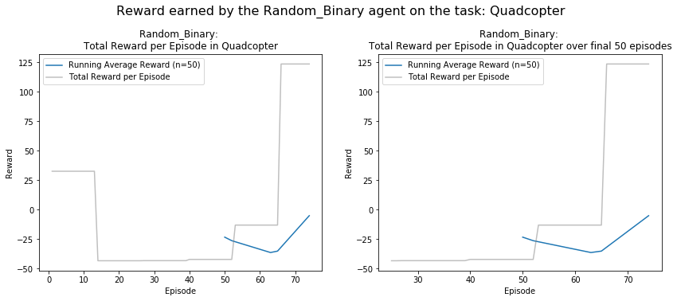

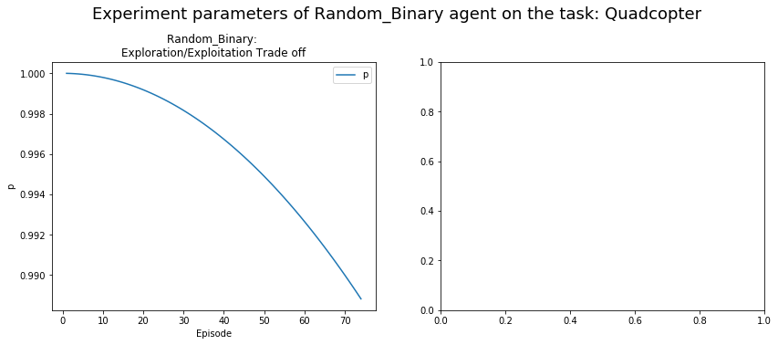

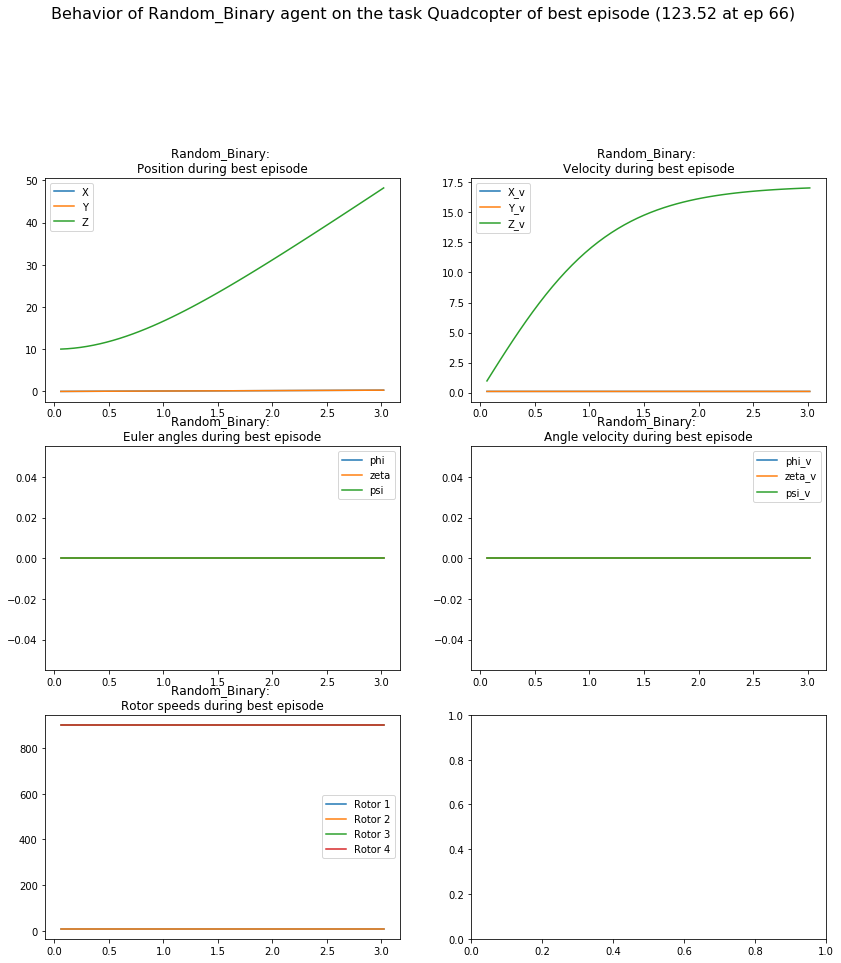

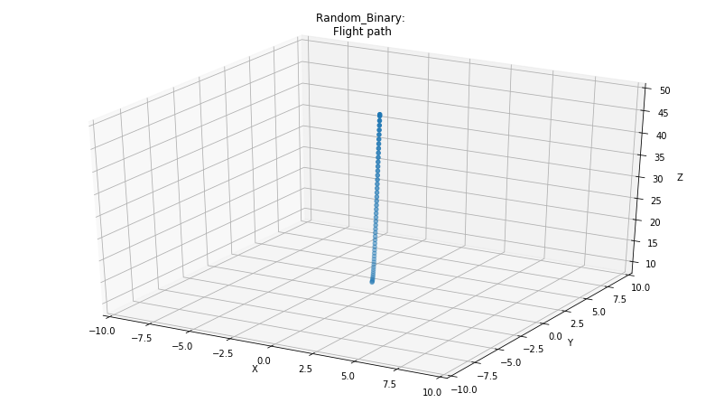

```python
reward_function = None

vs.plot_training_rewards(results_train_binary_quad, 'Random_Binary', 'Quadcopter', 50, verbose=True, reward_function=reward_function)
vs.plot_quad_behavior(results_train_binary_quad, 'Random_Binary', 'Quadcopter')
```

Random binary agent finds a policy equivalent to what either DDPG agent eventually finds, but gets there in under 1 second of computation versus around 10 minutes training time for the DDPG agents.

## Plot the Rewards

Once you are satisfied with your performance, plot the episode rewards, either from a single run, or averaged over multiple runs.

Quite honestly I can't say that I am satisfied with the performance of my final DDPG agent. While it does learn the task of takeoff eventually, it does seem to get there more or less by chance. In any case, here again is the visualization of the DDPG training and flying behavior:

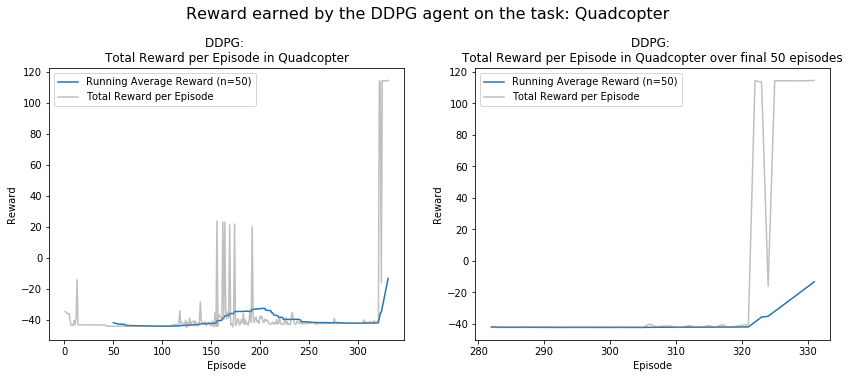

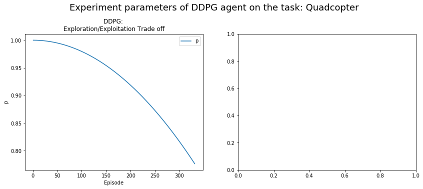

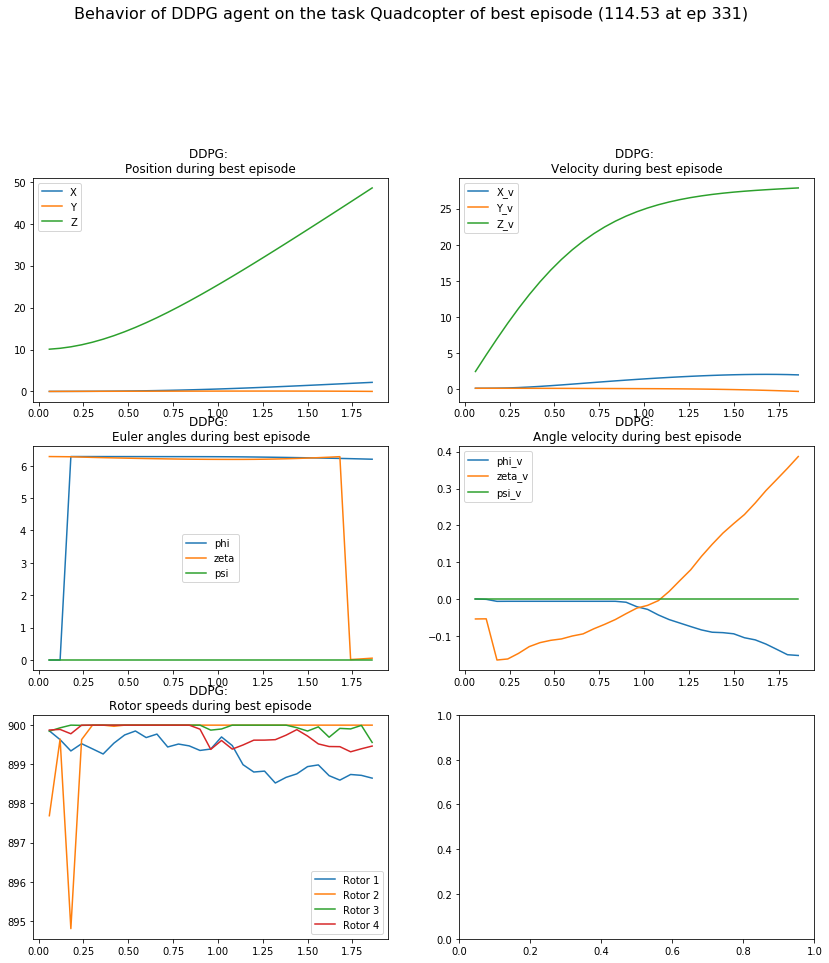

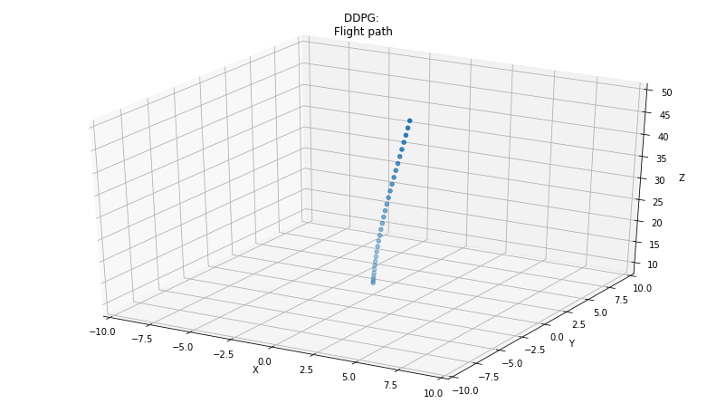

```python
vs.plot_training_rewards(results_train_ddpg_quad , 'DDPG', 'Quadcopter', 50, verbose=True, reward_function=reward_function)
vs.plot_quad_behavior(results_train_ddpg_quad , 'DDPG', 'Quadcopter')
```

## Reflections

**Question 1**: Describe the task that you specified in `task.py`. How did you design the reward function?

**Answer**:

I started this project with the reward function that comes with task.py and the DDPG agent that was given in the project. My task was to take off from an initial position 0,0,10 to 0,0,30. I wanted to start with a more ambitious task, but following advice from other students started with an "easier" task.

The default agent and task did poorly - in that it continuously crashed straight to the ground, with minimal diviations on the Y and X axis.

I then began changed the reward function based on the input of this video: https://www.youtube.com/watch?v=0R3PnJEisqk

My thinking for this design was as follows: The agent should be discouraged from crashing by a large negative reward. It should be encouraged to reach the goal by a large positive reward. For any non-terminating state in between, it should be rewarded as long as it is up in the air, with a sloped increase in reward as it gets closer to the target. The small positive reward should prevent the agent from intentionally crashing as every step in the air accumulates additional reward. A large positive reward on reaching the goal teaches the agent the desired end state. The reward is kept very large to ensure that hovering around the target collecting small reward will yield less total reward than reaching the target. Finally, a negative reward is given for flying out of the environment.

With this reward function the agent should be incentivised:

- To not crash
- To not fly out of the environment
- To stay airborne as long as possible
- To maneuveur closer to the target
- To try to end the episode at the target

Any of these incentives should contribute to a stable and finally desired flying behavior.

**Question 2**: Discuss your agent briefly, using the following questions as a guide:

- What learning algorithm(s) did you try? What worked best for you?
- What was your final choice of hyperparameters (such as $\alpha$, $\gamma$, $\epsilon$, etc.)?
- What neural network architecture did you use (if any)? Specify layers, sizes, activation functions, etc.

**Answer**:

**Algorithm**

I went with the DDPG algorithm suggested by the project supplementals. Initially I worked with the DDPG implementation as provided by Udacity. I then went on to modify the implementation to mirror the architecture proposed by Lillicrap, Timothy P., et al. Somewhat embarassingly, my half-serious benchmark agent Random_Binary_Agent remained the best performing agent at the end of the project.

**Parameters**

My final choice of hyperparameters were as follows:

| Parameter | Value |
| --- | --- |
| mu | 0. |
| theta | 0.15 |
| sigma | 0.2 |
| gamma | 0.99 |
| tau | 0.1 |
| buffer_size | 100000 |
| batch_size | 256 |

I gave the task the following initialization:

Small initial velocity to the quadcopter

| Initialization | Value |
| --- | --- |
| Velocities | [.1, .1, .1] |
| Angle Velocities | [0., 0., 0.] |
| Pose | [0., 0., 10., 0., 0., 0.] |

Action range and action repeat:

| Action parameter | Value |
| --- | --- |
| Action lowest | 10 |
| Action highest | 900 |
| Action repeat | 3 |

Finally, the success condition: Euclidean distance to the target position. Anything lower than this is considered a success.

Distance to succeed: 2

**Architecture**

Actor:

Actor network is composed of two fully connected hidden layers of 400 and 300 nodes, respectively. Both are activated using ReLU. This is followed by a fully connected output layer, with sigmoid activation. The output is further scaled to fit the action range of of the Task.

The Actor network uses an Adam optimizer with learning rate 0.0001.

Critic:

The critic architecture keeps the overall layout from the Udacity example implementation, with a separate pathway for the state and action, and a final fully connected layer to join the two.

The Critic network uses an Adam optimizer with learning rate 0.001 (different from Actor - again taken from Lillicrap, Timothy P., et al.).

Both the action and the state pathway have two hidden layers of 400 and 300 nodes, respectively. Both are activated using ReLU.

The Critic final output is regularized with L2 weight decay of 0.01.

For both the Actor and the Critic network, the final layer is initialized uniformly between -0.003 and 0.003, to ensure initial values near zero.  
The hidden layers are initialized with a uniform distribution from -1/√n to 1/√n where n is the number of incoming connections coming into a given layer from the previous layer’s output.

Both initializations are taken from Lillicrap, Timothy P., et al.

**Question 3**: Using the episode rewards plot, discuss how the agent learned over time.

- Was it an easy task to learn or hard?
- Was there a gradual learning curve, or an aha moment?
- How good was the final performance of the agent? (e.g. mean rewards over the last 10 episodes)

**Answer**:

**Aha moment**

Certainly the DDPG agent (both simple and final version) finds a successful policy in an "aha" moment. This becomes obvious when we compare the learning (reward) curves of DDPG at the TakeOff task vs the curve of the mountaincar environment. In mountaincar, after some initial probing the curve quickly slopes up and converges against a level well above the success condition.

In the quadcopter task, the agent is stuck for a long time in the absolute minumum, crashing into the ground. Rarely it finds a local optimum by flying not to the target, but not crashing either (running out of bounds of the simulation). If this happens, the switch to the better policy is instant as soon as the better policy is found. The agent does not gradually work towards a better policy at all.

Finally, once a successfully policy is found, the reward curve shoots straight up (aha!) as the agent adopts the new policy as soon as it is discovered.

**Last 10 episode performance**

Once a successful policy is found, the agent does perform very well on it, succeeding in taking off in 9 out the past 10 episodes. Of course, this is A) because that is precisily the condition on which the training process terminates and B) the three rotor configurations the agent eventually find are near optimal for the simple task of taking off. But this is more a property of the simplistic task than of the agent's policy.

**Question 4**: Briefly summarize your experience working on this project. You can use the following prompts for ideas.

- What was the hardest part of the project? (e.g. getting started, plotting, specifying the task, etc.)
- Did you find anything interesting in how the quadcopter or your agent behaved?

**Answer**:

This was for sure the hardest project by far for me. There was not necessarily a single hardest part. Getting started was straightforward, if the agent from the project supplementals is used as a template.

Implementing the reward function was quite a bit of work and took a bit of research. Most of the work however went into specifying success and failure conditions for the agent, and less any sophisticated reward curves. It was more conventional coding work than design work. Telling the agent when it succeeds and when it fails and rewarding accordingly seems to have a much bigger impact than the way continuous rewards towards the goal are given.

Keeping track of the different experiments was a challenge. Without implementing my infrastructure of running experiments (remotely) and recording results as well as parameters I would have gotten lost there. Sacred and Omniboard were a godsend here to get a feel which changes makes a difference.

Plotting the results was more busywork writing matplotlib graphs than anything else. Once I decided to dump all data logs into the same Pandas dataframe template and wrote my plotting helpers visualizing became much more streamlined.

The most *interesting* thing about the behavior of my agent was also the most frustrating. That is my main roadblock, that the agent quickly resolves to choosing either the minimum or maximum of the action range instead of from the continuous range. Limited as such, the agent is only able to solve simple tasks more or less tailed to this limitation. It was frustrating that I could not overcome this problem even after weeks of work. I also got the feeling that because of these limitations, the hyperparameters (with the exception of tau) didn't end up making much of a difference either way, or were overshadowed by the impact of the initialization.

Finally, at many points I was reminded of the previously mentioned article on why Deep Reinforcement Learning Doesn't Work Yet by Alexir Pan: https://www.alexirpan.com/2018/02/14/rl-hard.html

The biggest issue from the article I found is probably the lack of reproducability. My agent would sometimes solve the task in 50 episodes. But then it takes a few attempts of a 1000 episodes to reproduce any success at all. This makes it very difficult to start trusting your implementation.